# Multivariate normal Distribution: Important Facts

1/25/2020

# Definition

**Multivariate normal distribution** is the most important distribution in Statistics, and its properties are very useful in modern Statistical research. First, we need to specify the definition of Multivariate normal distribution. And there are 4 definitions of $p-$dimensional Multivariate normal distribution

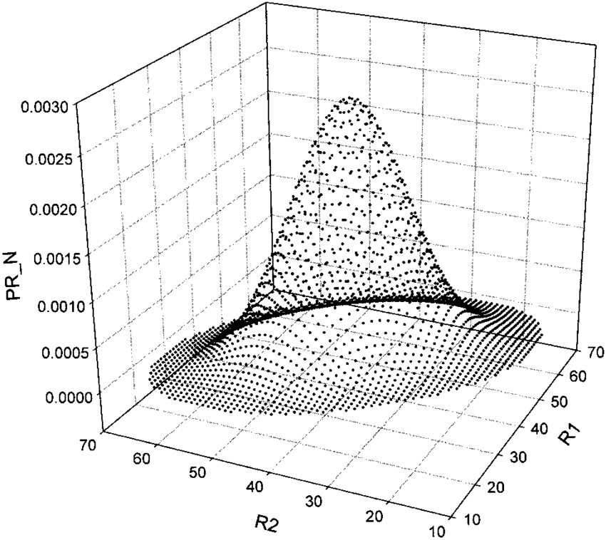

- Density function:
  $$f(X)=(2\pi)^{-\frac{p}{2}}|\Sigma|^{-\frac{1}{2}}\exp\left\{-\frac{1}{2}(X-\mu)^T\Sigma^{-1}(X-\mu)\right\}.$$
  where $\Sigma$ is a positive definite matrix.
- Characteristic function:
  $$\phi_{X}(t)=\exp \left(i t^{T} \mu-\frac{1}{2} t^{T} \Sigma t\right).$$
- If any linear combination of $p-$dimensional random multivariate $X$ is a univariate normal random variable, i.e., $a^TX$ is univariate normal for any $a\in \mathbb{R}^p$, then $X$ is a $p-$dimensional multivariate normal distribution.
- If $X_1,...,X_p$ are i.i.d. random univariate normal variables, then $X=(X_1,...,X_p)^T$ is a $p-$dimensional multivariate normal distribution.

# Degenerate multivariate normal distributions

Now let’s see singular or degenerate multivariate normal distributions. Suppose that $X$ is a $p-$dimensional multivariate normal distribution with mean vector $\mu$ and covariance matrix $\Sigma$ of rank $r<p$. Then there’s a nonsingular matrix $B$ s.t.
$$B\Sigma B^T=\left(\begin{matrix}I_r &0\\
0 & 0\end{matrix}\right),$$
and the transformation
$$BX=V=\left(\begin{matrix}V_1\\
V_2\end{matrix}\right)$$
is a $p-$dimensional multivariate normal distribution with covariance matrix $B\Sigma B^T$. Thus the covariance matrix of $V_2$ is $0$, then there exists some $\nu_2 \in \mathbb{R}^{p-r}$ s.t.
$$V_2=\nu_2$$
with probability 1. Now partition
$$B^{-1}=\left(\begin{matrix}C & D\end{matrix}\right),$$
then
$$X=B^{-1}V=CV_1+DV_2.$$
Therefore with probability 1,
$$X=CV_1+D\nu_2$$
holds, which means that $X$ is dominated by a low-dimensional random space.

# A trap

An important property of multivariate normal distribution is that if $(X_1,X_2)$ is multivariate normal distributed and $\operatorname{Cov}(X_1,X_2)=0$, then $X_1$ and $X_2$ are independent. The conclusion can be verified by characteristic function. However, **this property only holds for multivariate normal distribution.** Given two arbitrary normal random variables $X_1$ and $X_2$, if $\operatorname{Cov}(X_1,X_2)=0$, we can’t say that $X_1$ and $X_2$ are independent.

# Conditional distribution

Conditional distribution of multivariate normal distribution is very important, which leads a explanation of [linear regression](http://www.stat.yale.edu/Courses/1997-98/101/linreg.htm). And the rest part of this blog will focus on the conditional distribution. Let $X$ be a $p-$dimensional Multivariate normal distribution satisfies that
$$\mathbb{E}(X)=\left(\begin{matrix}\mu_1\\
\mu_2\end{matrix}\right),\quad \operatorname{Cov}(X)=\left(\begin{matrix}\Sigma_{11} & \Sigma_{12}\\
\Sigma_{21} & \Sigma_{22}\end{matrix}\right).$$
Then given $X_3,...,X_p$, the conditional covariance matrix of $(X_1,X_2)$ is
$$\Sigma_{11.2}=\Sigma_{11}-\Sigma_{12}\Sigma_{22}^{-1}\Sigma_{21}.$$
According to the inversion of blocked matrix,
$$\Sigma^{-1}=\left(\begin{matrix}
\Sigma_{11.2}^{-1} & -\Sigma_{11.2}^{-1}\Sigma_{12}\Sigma_{22}^{-1}\\
-\Sigma_{22}^{-1}\Sigma_{21}\Sigma_{11.2}^{-1} & \Sigma_{22}^{-1}+\Sigma_{22}^{-1}\Sigma_{21}\Sigma_{11.2}^{-1}\Sigma_{12}\Sigma_{22}^{-1}
\end{matrix}\right)$$
And by the matrix theory, a matrix is a diagonal matrix if and only if the inverse of the matrix is a diagonal matrix. Therefore,
$$\operatorname{Cov}\left(X_{1}, X_{2} | X_{k, \neq 1, 2}\right) \neq 0$$
is equivalent to $\omega_{12}\neq 0$ where $\omega_{12}$ is the $(1,\ 2)$ element of $\Omega=\Sigma^{-1}$. Generallly we have
$$\operatorname{Cov}\left(X_{i}, X_{j} | X_{k}, k \neq i, j\right) \neq 0 \Leftrightarrow \omega_{i j} \neq 0.$$
And this property is the basic of the [Gaussian graphical model](https://en.wikipedia.org/wiki/Graphical_models_for_protein_structure). $\{X_1,...,X_p\}$ are some vertices, $X_i$ and $X_j$ will be connected by an edge if
$$\operatorname{Cov}\left(X_{i}, X_{j} | X_{k, \neq i, j}\right) \neq 0.$$
Moreover, the regression form of $X_1$ on $X_2,...,X_p$ is
$$X_1-\mu_1 = \Sigma_{1,-1}\Sigma_{-1,-1}^{-1}(X_{-1}-\mu_{-1})+\varepsilon_1,$$
which can be written as
$$X_1-\mu_1 = (X_{-1}-\mu_{-1})\boldsymbol{\beta}_1+\varepsilon_1,$$
where $\boldsymbol{\beta}_1=(\beta_{12},...,\beta_{1p})$. Note that the first row of $\Sigma^{-1}$ is
$$\left(\sigma_{11.-1}^{-1}\quad -\sigma_{11.-1}^{-1}\Sigma_{1,-1}\Sigma_{-1,-1}^{-1}\right),$$
where $\sigma_{11.-1}=\sigma_{11}-\Sigma_{1,-1}\Sigma_{-1,-1}^{-1}\Sigma_{-1,1}$ and which leads that $\beta_{1j}=-\frac{\omega_{1j}}{\omega_{11}}$. Similarly, the regression form of $X_2$ on $X_1,...,X_p$ is
$$X_2-\mu_2 = (X_{-2}-\mu_{-2})\boldsymbol{\beta}_2+\varepsilon_2,$$
where
$$\boldsymbol{\beta}_2=\left(-\frac{\omega_{21}}{\omega_{22}},\cdots,-\frac{\omega_{2p}}{\omega_{22}}\right)^T.$$
Using the fact $\varepsilon_1$ is independent with $X_{-1}$, we have
$$\begin{align*}
\operatorname{Cov}(\varepsilon_1, \varepsilon_2)&=\operatorname{Cov}\left(X_1-\mu_1 - \Sigma_{1,-1}\Sigma_{-1,-1}^{-1}(X_{-1}-\mu_{-1}),\ \frac{\omega_{21}}{\omega_{22}}X_1\right)\\
&=\frac{\omega_{21}}{\omega_{22}}\sigma_{11.-1}\\
&=\frac{\omega_{21}}{\omega_{22}\omega_{11}},
\end{align*}$$
which implies that
$$\omega_{ij}= 0 \Leftrightarrow \operatorname{Cov}(\varepsilon_i, \varepsilon_j)= \frac{\omega_{ij}}{\omega_{ii}\omega_{jj}} =0.$$
**Therefore we can perform hypothesis test on the regression residuals to find the support of precise matrix.**